# PCIT-CoS-Waitlist RCT Paper 1: BITSEA Competence

Nancy Briggs

2024-04-29

### BITSEA Competence

Output run on 2024-04-29

Values have been calculated by:

- missing values are: 3, 888, 999, 9999
- sum computed from: pf1, pf5, pf10, pf13, pf15, pf19, pf20, pf22, pf25, pf29, pf31

#### Descriptives

| group | time | n | mean | sd | median | min | max |
| --- | --- | --- | --- | --- | --- | --- | --- |
| 1 | 1 | 29 | 14.552 | 3.869 | 15 | 4 | 21 |
| 1 | 2 | 24 | 16.667 | 3.644 | 17 | 4 | 22 |
| 1 | 3 | 18 | 16.278 | 4.535 | 18 | 2 | 21 |
| 2 | 1 | 27 | 15.926 | 2.881 | 17 | 9 | 20 |
| 2 | 2 | 13 | 15.923 | 2.660 | 16 | 12 | 20 |
| 2 | 3 | 5 | 17.000 | 2.739 | 17 | 13 | 20 |
| 3 | 1 | 26 | 15.500 | 3.547 | 16 | 7 | 21 |
| 3 | 2 | 21 | 15.429 | 3.501 | 15 | 5 | 20 |
| 3 | 3 | 0 | NaN | NA | NA | Inf | -Inf |

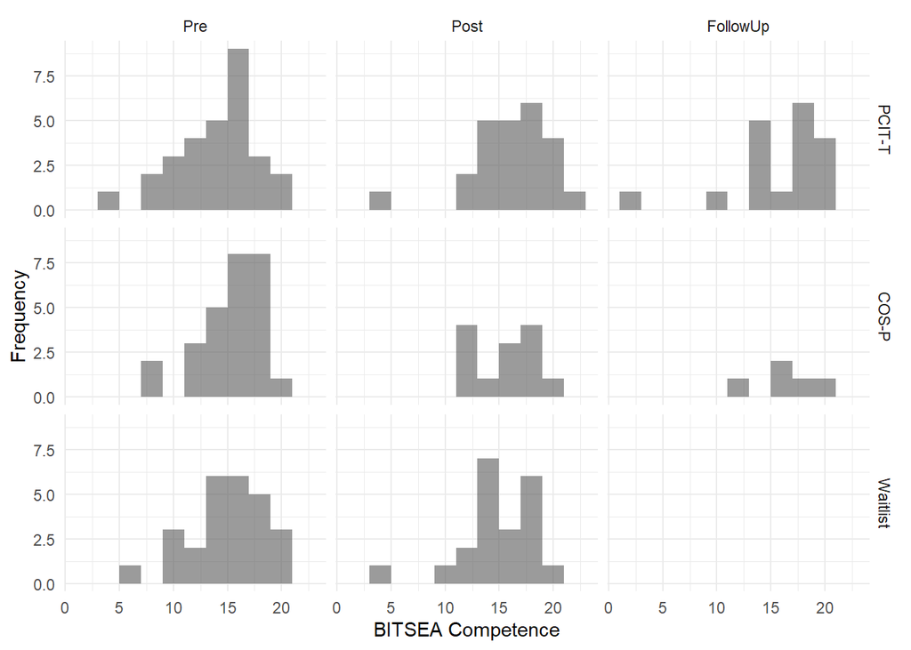

#### Model & Results

A linear mixed model with random effect for individual and fixed effects of group, time and the interaction was run. Estimated marginal means were obtained, and contrasts specified to test Hypothesis 1 and Hypothesis 2.

```
## fixed-effect model matrix is rank deficient so dropping 1 column / coefficient
```

```
## refitting model(s) with ML (instead of REML)
```

|  | Effect | npar | AIC | BIC | logLik | deviance | Chisq | Df | Pr(>Chisq) |
| --- | --- | --- | --- | --- | --- | --- | --- | --- | --- |
| result0 | Intercept | 3 | 805.394 | 814.676 | -399.697 | 799.394 | NA | NA | NA |
| result1 | Group | 5 | 808.817 | 824.286 | -399.409 | 798.817 | 0.577 | 2 | 0.749 |
| result2 | Time | 7 | 803.604 | 825.261 | -394.802 | 789.604 | 9.213 | 2 | 0.010 |
| result3 | Group*Time | 10 | 803.950 | 834.887 | -391.975 | 783.950 | 5.654 | 3 | 0.130 |

This is the ANOVA table for the model. p-values are likelihood ratio tests for adding the new term to the model just before. A p-value <0.05 indicates that adding that term results in better model fit. The most important p-value is the interaction p-value. Here, there is no evidence that the pattern of change over time is different among the groups (p=0.1296927).

```r
summary(result3)
```

```
## Linear mixed model fit by REML. t-tests use Satterthwaite's method [
## lmerModLmerTest]
## Formula: outcome ~ group * time + (1 | id)
##    Data: dat
##
## REML criterion at convergence: 777.7
##
## Scaled residuals:
##     Min      1Q  Median      3Q     Max
## -1.6459 -0.4630  0.0579  0.4400  2.0013
##
## Random effects:
##  Groups   Name        Variance Std.Dev.
##  id       (Intercept) 9.945    3.154
##  Residual             2.644    1.626
## Number of obs: 163, groups:  id, 83
##
## Fixed effects:
##              Estimate Std. Error      df t value Pr(>|t|)
## (Intercept)   14.5517     0.6589 94.3592  22.087  < 2e-16 ***
## group2         1.3742     0.9489 94.3592   1.448 0.150855
## group3         0.8965     0.9524 95.4755   0.941 0.348928
## time2          1.6291     0.4651 77.5338   3.503 0.000768 ***
## time3          1.3383     0.5189 78.2937   2.579 0.011775 *
## group2:time2  -1.4474     0.7752 81.1802  -1.867 0.065480 .
## group3:time2  -1.3738     0.6873 78.5601  -1.999 0.049097 *
## group2:time3  -0.3377     1.0596 81.3175  -0.319 0.750764
## ---
## Signif. codes:  0 '***' 0.001 '**' 0.01 '*' 0.05 '.' 0.1 ' ' 1
##
## Correlation of Fixed Effects:
##             (Intr) group2 group3 time2  time3  grp2:2 grp3:2
## group2      -0.694
## group3      -0.692  0.480
## time2       -0.297  0.207  0.206
## time3       -0.267  0.185  0.184  0.440
## group2:tim2  0.178 -0.257 -0.123 -0.600 -0.264
## group3:tim2  0.201 -0.140 -0.302 -0.677 -0.298  0.406
## group2:tim3  0.131 -0.188 -0.090 -0.215 -0.490  0.350  0.146
## fit warnings:
## fixed-effect model matrix is rank deficient so dropping 1 column / coefficient
```

#### Estimated Means & Change

Estimated means for each Treatment and Time are presented. In addition, within-group change between time points is presented with 95% CIs.

##### Group mean difference at each timepoint

Effect sizes all calculated by the pooled T1 SD of the outcome. Adjusted p-value from Bonferroni correction.

Group Differences at Each Time Point

| Group Difference | Time | Mean | SE | t | p | adj p | Lower CL | Upper CL | Effect Size | Lower CL | Upper CL |
| --- | --- | --- | --- | --- | --- | --- | --- | --- | --- | --- | --- |
| 1 - 2 | 1 | -1.374 | 0.949 | -1.448 | 0.321 | 0.453 | -3.634 | 0.885 | -0.401 | -0.721 | -0.094 |
| 1 - 3 | 1 | -0.897 | 0.952 | -0.941 | 0.616 | 1.000 | -3.164 | 1.371 | -0.261 | -0.696 | 0.336 |
| 2 - 3 | 1 | 0.478 | 0.969 | 0.493 | 0.875 | 1.000 | -1.830 | 2.785 | 0.139 | -0.304 | 0.665 |
| 1 - 2 | 2 | 0.073 | 1.061 | 0.069 | 0.997 | 1.000 | -2.443 | 2.589 | 0.021 | -0.329 | 0.492 |
| 1 - 3 | 2 | 0.477 | 0.993 | 0.481 | 0.881 | 1.000 | -1.882 | 2.837 | 0.139 | -0.293 | 0.488 |
| 2 - 3 | 2 | 0.404 | 1.084 | 0.373 | 0.926 | 1.000 | -2.166 | 2.974 | 0.118 | -0.323 | 0.517 |
| 1 - 2 | 3 | -1.036 | 1.284 | -0.807 | 0.699 | 1.000 | -4.076 | 2.003 | -0.302 | -0.676 | 0.275 |
| 1 - 3 | 3 | NA | NA | NA | NA | NA | NA | NA | NA | NA | NA |
| 2 - 3 | 3 | NA | NA | NA | NA | NA | NA | NA | NA | NA | NA |

* Effect size scaled by pooled T1 SD  
† ES 95% Bootstrapped Percentile CI limits  
‡ If you want a positive ES (and it is calculated as negative), be sure to switch the signs and positions of the lower and upper CIs.

##### Change within each group

Within-Group Change and Effect Sizes

| Change | Group | Mean | SE | t | p | adj p | Lower CL | Upper CL | Effect Size | Lower CL | Upper CL |
| --- | --- | --- | --- | --- | --- | --- | --- | --- | --- | --- | --- |
| 1 - 2 | 1 | -1.629 | 0.465 | -3.500 | 0.002 | 0.002 | -2.741 | -0.517 | -0.475 | -0.584 | -0.233 |
| 1 - 3 | 1 | -1.338 | 0.519 | -2.576 | 0.031 | 0.036 | -2.579 | -0.097 | -0.390 | -0.540 | -0.082 |
| 2 - 3 | 1 | 0.291 | 0.523 | 0.556 | 0.844 | 1.000 | -0.959 | 1.541 | 0.085 | -0.113 | 0.320 |
| 1 - 2 | 2 | -0.182 | 0.622 | -0.292 | 0.954 | 1.000 | -1.665 | 1.302 | -0.053 | -0.204 | 0.274 |
| 1 - 3 | 2 | -1.001 | 0.926 | -1.081 | 0.529 | 0.849 | -3.211 | 1.210 | -0.292 | -0.722 | 0.290 |
| 2 - 3 | 2 | -0.819 | 0.937 | -0.874 | 0.658 | 1.000 | -3.057 | 1.419 | -0.239 | -0.568 | 0.193 |
| 1 - 2 | 3 | -0.255 | 0.507 | -0.504 | 0.870 | 1.000 | -1.466 | 0.955 | -0.074 | -0.342 | 0.051 |
| 1 - 3 | 3 | NA | NA | NA | NA | NA | NA | NA | NA | NA | NA |
| 2 - 3 | 3 | NA | NA | NA | NA | NA | NA | NA | NA | NA | NA |

* Effect size scaled by pooled T1 SD  
† ES 95% Bootstrapped Percentile CI limits  
‡ If you want a positive ES (and it is calculated as negative), be sure to switch the signs and positions of the lower and upper CIs.

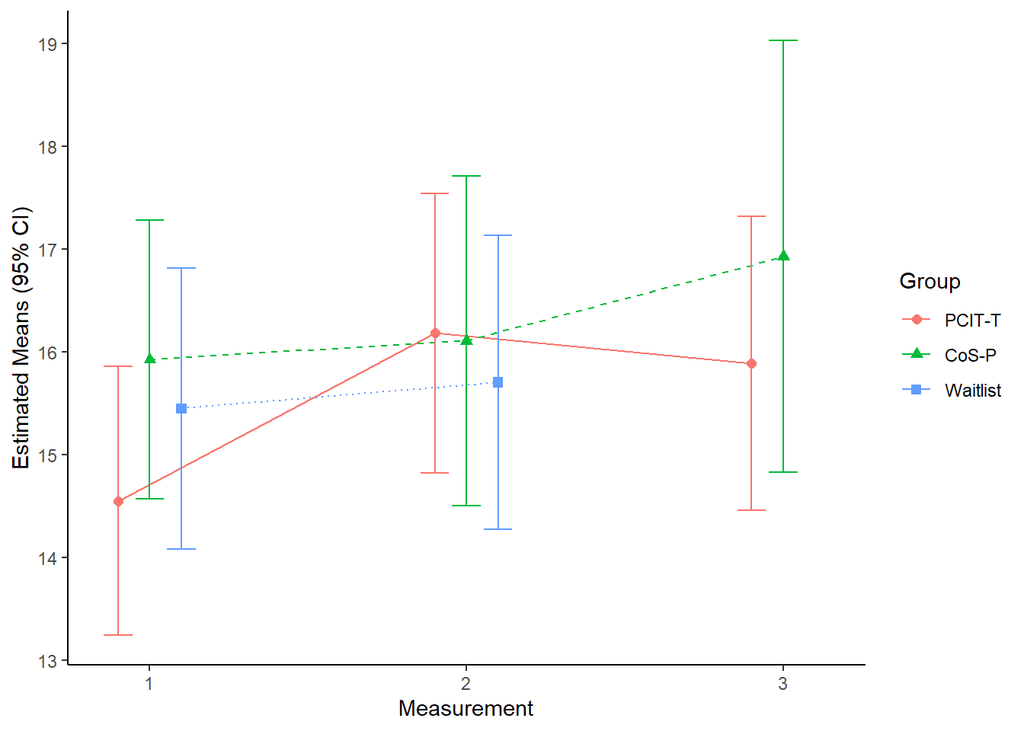

#### Hypothesis 1

We hypothesize that from baseline (‘T1’) to post-treatment/waitlist (‘T2’) there will be a gradient effect, whereby parent-child dyads who receive PCIT-T will show the greatest gains and parent-child dyads who receive no treatment will show the least gains. For the outcome, then, the null hypothesis is:

$H_0: \text {mean change}(\text{PCIT-T}) = \text {mean change}(\text{CoS-P}) = \text {mean change}(\text{Waitlist})$ $H_A: \text {mean change}(\text{PCIT-T}) > \text {mean change}(\text{CoS-P}) > \text {mean change}(\text{Waitlist})$

This is a joint hypothesis test.

First, confirming that the ordering of the means is as hypothesized:

```
## group = 1:
##  contrast estimate    SE   df t.ratio p.value
##  1 - 2      -1.629 0.465 77.9  -3.500  0.0022
##  1 - 3      -1.338 0.519 78.6  -2.576  0.0314
##  2 - 3       0.291 0.523 76.5   0.556  0.8437
##
## group = 2:
##  contrast estimate    SE   df t.ratio p.value
##  1 - 2      -0.182 0.622 83.6  -0.292  0.9540
##  1 - 3      -1.001 0.926 82.6  -1.081  0.5288
##  2 - 3      -0.819 0.937 78.7  -0.874  0.6582
##
## group = 3:
##  contrast estimate    SE   df t.ratio p.value
##  1 - 2      -0.255 0.507 79.8  -0.504  0.8696
##  1 - 3      nonEst    NA   NA      NA      NA
##  2 - 3      nonEst    NA   NA      NA      NA
##
## Degrees-of-freedom method: kenward-roger
## P value adjustment: tukey method for comparing a family of 3 estimates
```

| contrast | group | t1t2change | quality | p.value |
| --- | --- | --- | --- | --- |
| 1 - 2 | 1 | 1.629 | increase t1 to t2 | 0.002 |
| 1 - 2 | 2 | 0.182 | increase t1 to t2 | 0.954 |
| 1 - 2 | 3 | 0.255 | increase t1 to t2 | 0.870 |

Is the ordering of change satisfied?

Greatest to least change from t1 to t2: Order not satisfied

Note that I interpreted an increase in scores as being “better”. If a decrease in scores is “better” then these change values should be interpreted in that light.

```
##   (Intercept) group2 group3 time2 time3 group2:time2 group3:time2 group2:time3
## 1           0      0      0     0     0            1            0            0
## 2           0      0      0     0     0           -1            1            0
```

```
##
##   General Linear Hypotheses
##
## Linear Hypotheses:
##        Estimate
## 1 == 0 -1.44744
## 2 == 0  0.07364
##
## Global Test:
##       F DF1 DF2  Pr(>F)
## 1 2.665   2 153 0.07285
```

p= 0.073. We have no evidence that there is a difference in the change over from Baseline to Post amongst the groups.

#### Hypothesis 2

##### Change from T2-T3

There will be a gradient of size of change from T2 to T3 such that the change in the PCIT-T group > the change in the CoS-P group. This isn’t really a gradient; it’s just 1 hypothesis.

First, the change in PCITT and COSP from time 2 to time 3:

```
## group = 1:
##  time emmean    SE    df lower.CL upper.CL
##  1      14.6 0.659  94.7     13.2     15.9
##  2      16.2 0.684 105.9     14.8     17.5
##  3      15.9 0.722 122.4     14.5     17.3
##
## group = 2:
##  time emmean    SE    df lower.CL upper.CL
##  1      15.9 0.683  94.7     14.6     17.3
##  2      16.1 0.810 139.5     14.5     17.7
##  3      16.9 1.062 149.0     14.8     19.0
##
## group = 3:
##  time emmean    SE    df lower.CL upper.CL
##  1      15.4 0.688  96.8     14.1     16.8
##  2      15.7 0.719 109.8     14.3     17.1
##  3    nonEst    NA    NA       NA       NA
##
## Degrees-of-freedom method: kenward-roger
## Confidence level used: 0.95
```

```
## group = 1:
##  contrast estimate    SE   df lower.CL upper.CL
##  1 - 2      -1.629 0.465 77.9   -2.741  -0.5170
##  1 - 3      -1.338 0.519 78.6   -2.579  -0.0974
##  2 - 3       0.291 0.523 76.5   -0.959   1.5407
##
## group = 2:
##  contrast estimate    SE   df lower.CL upper.CL
##  1 - 2      -0.182 0.622 83.6   -1.665   1.3017
##  1 - 3      -1.001 0.926 82.6   -3.211   1.2095
##  2 - 3      -0.819 0.937 78.7   -3.057   1.4192
##
## group = 3:
##  contrast estimate    SE   df lower.CL upper.CL
##  1 - 2      -0.255 0.507 79.8   -1.466   0.9549
##  1 - 3      nonEst    NA   NA       NA       NA
##  2 - 3      nonEst    NA   NA       NA       NA
##
## Degrees-of-freedom method: kenward-roger
## Confidence level used: 0.95
## Conf-level adjustment: tukey method for comparing a family of 3 estimates
```

```r
## Specify contrast matrices
# Hyp1 is 1 df test
# could use alternative="less" ir alternative="greater" in glht
hyp2   <- matrix(c(0, 0,0, 0,0, -1,0,1 ),1)
hyp2F <- glht(result3, linfct = hyp2)
summary(hyp2F)
```

```
##
##   Simultaneous Tests for General Linear Hypotheses
##
## Fit: lmer(formula = outcome ~ group * time + (1 | id), data = dat)
##
## Linear Hypotheses:
##        Estimate Std. Error z value Pr(>|z|)
## 1 == 0    1.110      1.072   1.035    0.301
## (Adjusted p values reported -- single-step method)
```

```r
s<-summary(hyp2F, test = Ftest())
#also see this webpage for more on contrasts https://rcompanion.org/rcompanion/h_01.html



## Extract pvaue for evidence / no evidence
evidence = ifelse(s$test$pvalue<0.05, "evidence", "no evidence")
```

##### Change from T1-T3

```
##
##   General Linear Hypotheses
##
## Linear Hypotheses:
##        Estimate
## 1 == 0  -0.3377
##
## Global Test:
##        F DF1 DF2 Pr(>F)
## 1 0.1016   1 153 0.7504
```

p=0.7504. We have no evidence that the change from T1 to T3 is different for G1 and G2

#### Residuals

Assumptions of the model are met.

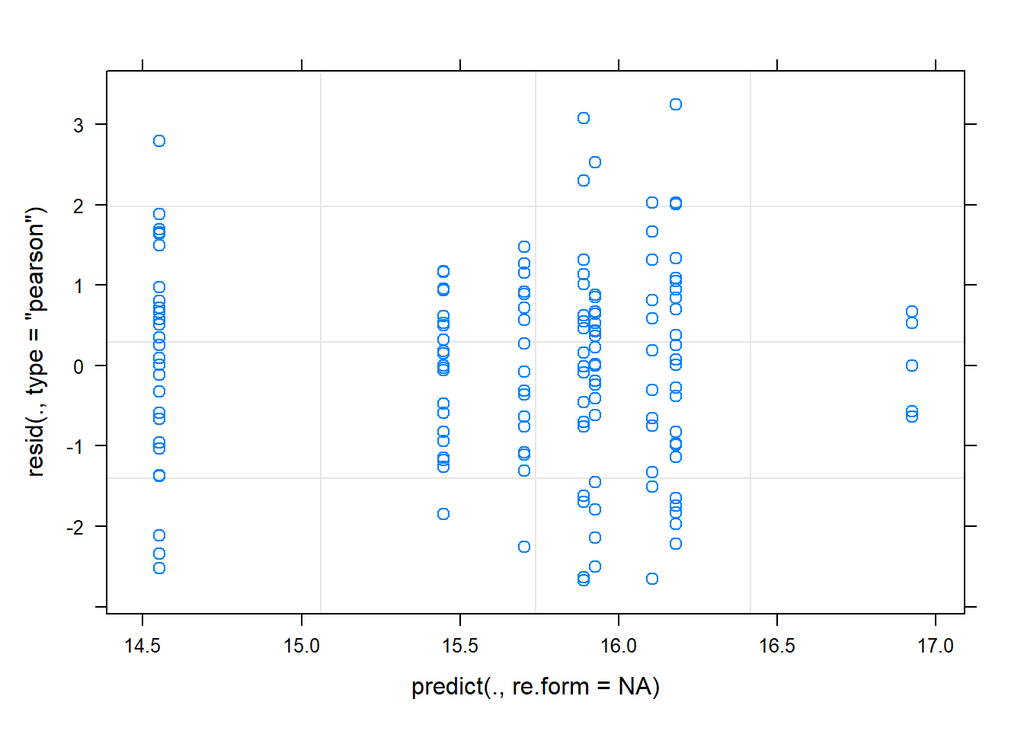

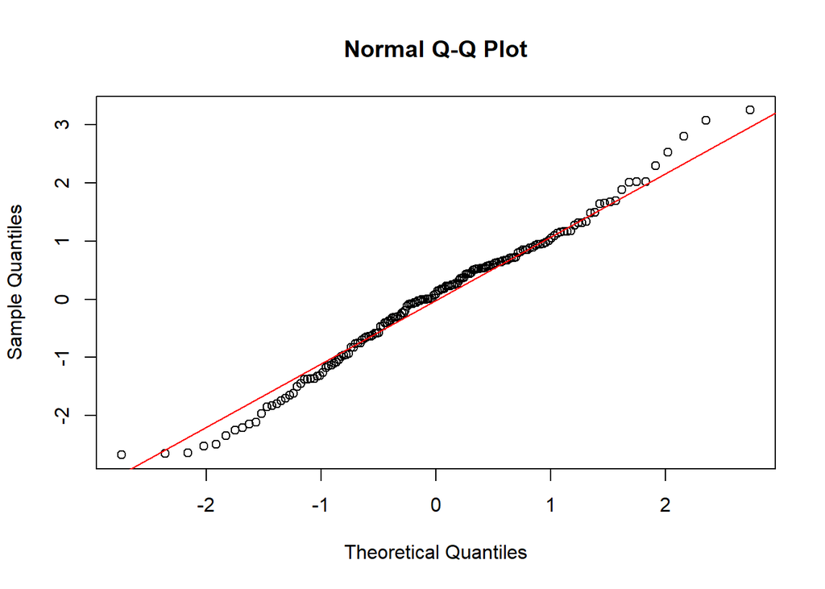

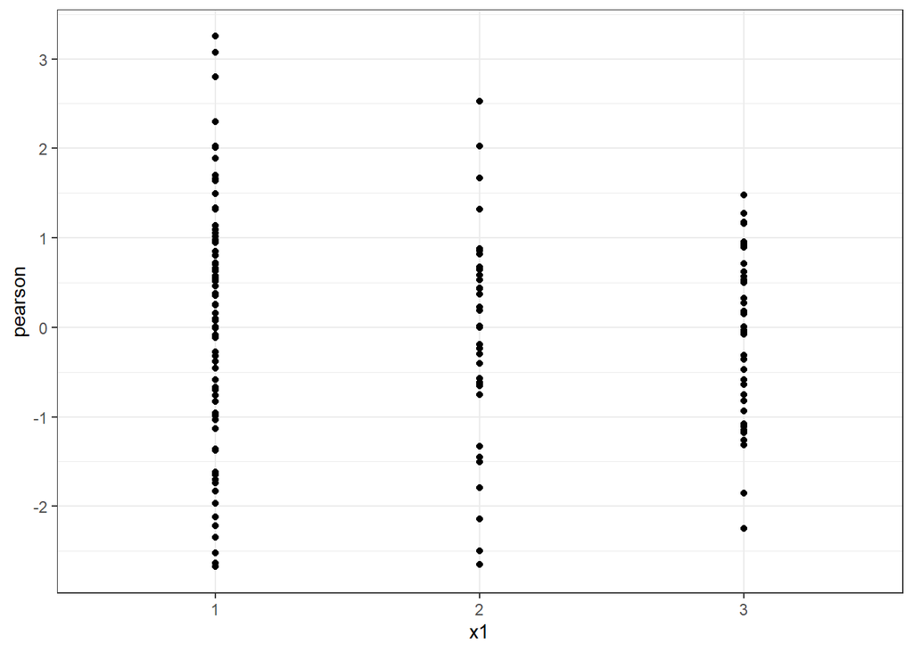

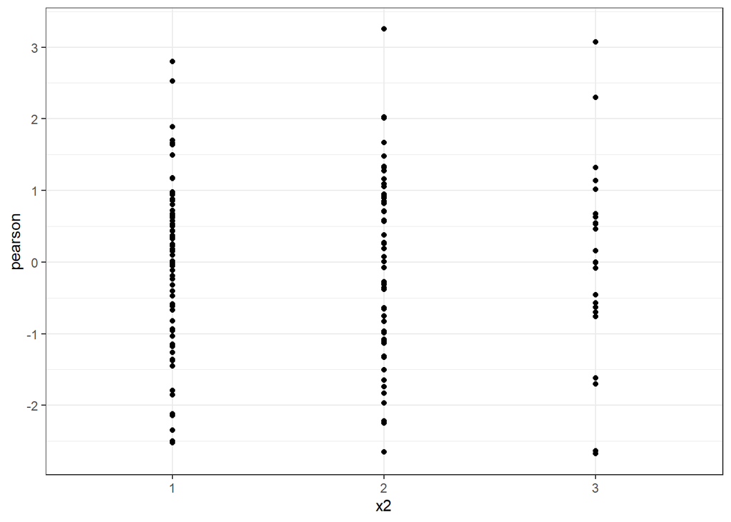

```r
rm(list = ls())
```